# Stable Isotope Mixing Models for Dietary Reconstruction

Module 1 · Introduction & Theoretical Foundations · 09:00–09:30

Author

Chronologies

Published

18 February 2026

One-Day Training Programme | Morning Session 09:00–12:30

# 1 Introduction & Theoretical Foundations

This module establishes the conceptual and mathematical foundations on which all subsequent mixing-model work rests. By the close of this 30-minute session you should be able to:

- Describe the physical basis of stable isotope fractionation
- Explain how trophic enrichment is quantified
- Discuss tissue-specific isotopic routing
- Situate dietary isotope analysis within the broader landscape of archaeological science

# 2 Principles of Stable Isotope Analysis

## 2.1 What is a Stable Isotope?

Isotopes are atoms of the same element that differ in neutron number and therefore in atomic mass. **Stable isotopes do not undergo radioactive decay** — unlike the radiogenic <sup>14</sup>C exploited in radiocarbon dating, the heavy stable isotopes relevant to dietary reconstruction are permanent constituents of the biosphere.

The two isotope systems used in the vast majority of palaeodietary studies are:

Table 1: Major stable isotope systems used in dietary reconstruction

| Isotope system | Light isotope | Heavy isotope | Abundance of heavy isotope |
| --- | --- | --- | --- |
| Carbon | <sup>12</sup>C | <sup>13</sup>C | 1.07 % |
| Nitrogen | <sup>14</sup>N | <sup>15</sup>N | 0.37 % |

The mass difference of 1 Da in each system is sufficient to produce measurable fractionation at every trophic transfer and biochemical transformation step that involves bond formation or breakage.

## 2.2 The Delta Notation

Because the absolute abundance of heavy isotopes is very small, isotope ratios are reported as per-mil (‰) deviations from an internationally agreed standard using the **delta (δ) notation**:

$$\delta X\ (\text{‰}) = \left[\frac{R_{\text{sample}}}{R_{\text{standard}}} - 1\right] \times 1000
\tag{1}$$

**Key interpretive rule**

A **more positive δ<sup>13</sup>C** value indicates incorporation of marine or C<sub>4</sub>-plant carbon. A **more positive δ<sup>15</sup>N** value indicates a higher trophic position, or consumption of manured or marine-derived protein.

## 2.3 Analytical Measurement

Stable isotope ratios are measured by **Isotope Ratio Mass Spectrometry (IRMS)**. In continuous-flow configurations (CF-IRMS), sample combustion and introduction to the mass spectrometer are integrated, enabling high-throughput analysis from as little as 0.3–1.0 mg of collagen. Typical analytical precision is ±0.1–0.2 ‰ (1σ) for both δ<sup>13</sup>C and δ<sup>15</sup>N — sufficient to resolve trophic-level differences, which are typically 3–5 ‰ per level for nitrogen.

## 2.4 The δ¹³C / δ¹⁵N Biplot

The most common visualisation in palaeodietary isotope work is the two-dimensional isotope biplot, which places individuals or populations within a reference space defined by food-web end-members.

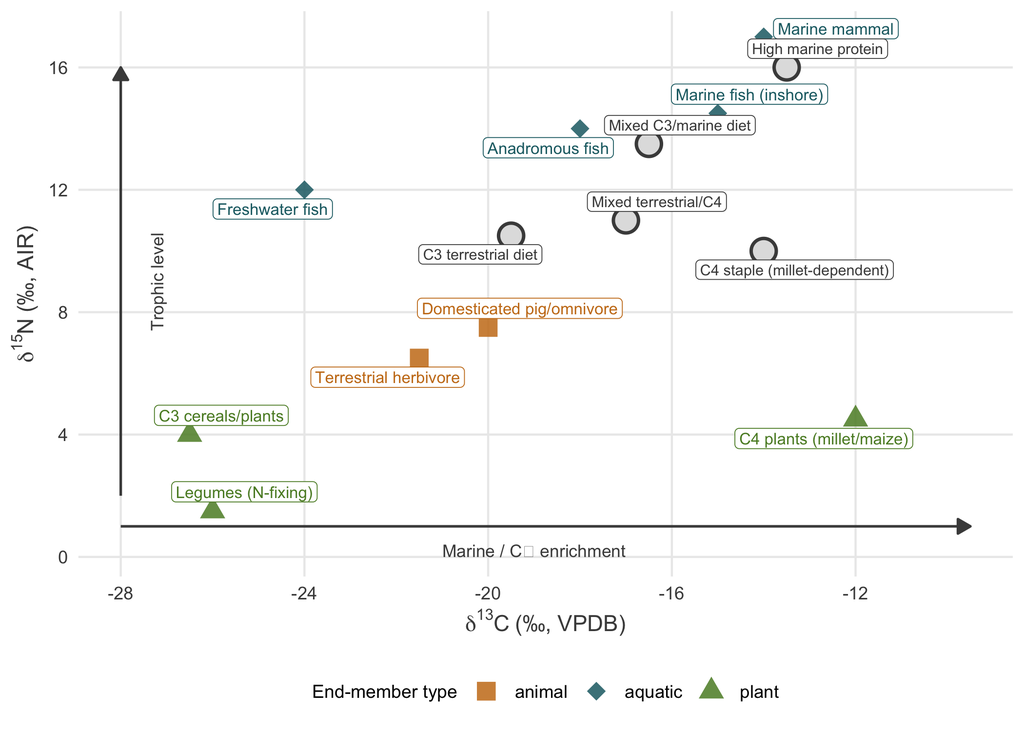

Human groups (grey open circles) sit above their dietary end-members by approximately one trophic step for δ<sup>15</sup>N (~+4 ‰) and close to or slightly above diet for δ<sup>13</sup>C (~+1 ‰), reflecting trophic enrichment factors discussed in Section 3.

**Summary: Why δ¹³C and δ¹⁵N?**

- δ<sup>13</sup>C discriminates between C<sub>3</sub> and C<sub>4</sub> plant consumers, and between terrestrial and marine protein sources.
- δ<sup>15</sup>N tracks trophic level: each step up the food chain enriches <sup>15</sup>N by ~3–5 ‰.
- Together, they place individuals in a 2-dimensional isotope space reflecting the main axes of dietary variation.
- Both can be measured simultaneously on a single IRMS run from a few milligrams of collagen.

# 3 Isotopic Fractionation and Trophic Level Effects

## 3.1 What is Fractionation?

Isotopic fractionation describes any process that alters the heavy-to-light isotope ratio of a substance relative to its source. Two categories are relevant:

**Equilibrium fractionation**

Arises from thermodynamic differences in bond energies involving isotopically distinct molecules. It is temperature-dependent and is the primary driver of <sup>13</sup>C partitioning during carbonate precipitation.

**Kinetic fractionation**

Arises when lighter isotopologues react faster than heavier ones. Biological enzyme-catalysed reactions — photosynthesis, transamination, deamination — are dominated by kinetic effects.

## 3.2 Trophic Enrichment Factors (TEFs)

When an organism synthesises tissue from dietary protein and energy substrates, fractionation at each biochemical step produces systematic isotopic enrichment relative to diet. These offsets are called **Trophic Enrichment Factors (TEFs)** or discrimination factors, denoted Δ (capital delta):

$$\Delta^{13}C = \delta^{13}C_{\text{tissue}} - \delta^{13}C_{\text{diet}}
\tag{2}$$

$$\Delta^{15}N = \delta^{15}N_{\text{tissue}} - \delta^{15}N_{\text{diet}}
\tag{3}$$

Published TEF estimates for human bone collagen vary considerably (Table 2). This variation is a major source of uncertainty in mixing models and must be propagated explicitly.

Table 2: Published Trophic Enrichment Factor estimates for human bone collagen relative to bulk diet

| Source | Δ¹³C (‰) | Δ¹⁵N (‰) |
| --- | --- | --- |
| Ambrose & Norr 1993 | +1.0 | +3.4 |
| Hedges & van Klinken 1992 | +0.8 | +4.0 |
| O’Connell et al. 2012 (controlled diet) | +0.8 ± 0.3 | +3.4 ± 0.4 |
| Bocherens & Drucker 2003 (review) | +0.6 – 1.3 | +3.0 – 5.0 |
| **Common default for mixing models** | **+1.0** | **+4.0** |

**Critical caveat on TEF values**

TEF values are **not universal constants**. They vary with tissue type, metabolic state, protein quality, and potentially with latitude and season. When constructing a mixing model, always justify your TEF choice and propagate its uncertainty using the standard deviation reported in your chosen source. Sensitivity analyses using alternative TEF values are strongly recommended before drawing dietary conclusions.

## 3.3 The Trophic Step Effect on δ¹⁵N

The approximately 3–5 ‰ enrichment in δ<sup>15</sup>N per trophic level arises because:

1. Dietary amino acids undergo transamination and deamination; <sup>14</sup>N-bearing compounds are preferentially excreted as urea or ammonia.
2. The heavier <sup>15</sup>N is therefore retained and concentrated in somatic protein.
3. With each successive trophic transfer the cumulative enrichment compounds, producing a predictable ladder of δ<sup>15</sup>N values through the food web.

In practice this produces the following approximate ranges:

Table 3: Approximate δ¹⁵N ranges by dietary category

| Taxon / dietary group | Approx. δ¹⁵N range (‰) |
| --- | --- |
| Legumes (N<sub>2</sub>-fixing) | 0 – 2 |
| C<sub>3</sub> terrestrial herbivores | 4 – 8 |
| Omnivorous humans (mixed plant/animal) | 8 – 12 |
| Marine or freshwater fish consumers | 13 – 18 |

**Archaeological confounders of δ¹⁵N**

Elevated δ<sup>15</sup>N is **not always** diagnostic of high-status meat consumption:

- **Manured soils** elevate baseline plant δ<sup>15</sup>N, cascading up the food web
- **Breastfed neonates** show apparent trophic elevation (~+2–3 ‰) relative to their mothers
- **Physiological stress** (starvation, illness) can increase tissue δ<sup>15</sup>N through net protein catabolism
- **Arid environments** tend to have systematically elevated δ<sup>15</sup>N baselines throughout the ecosystem

# 4 Isotopic Routing and Tissue-Specific Considerations

## 4.1 What is Isotopic Routing?

**Isotopic routing** refers to the differential biochemical fate of dietary macronutrients — proteins, lipids, and carbohydrates — during tissue synthesis. It has profound implications for interpreting collagen isotope data and for constructing mixing models, because collagen does not reflect bulk diet uniformly across all macronutrient classes.

## 4.2 Carbon Routing to Bone Collagen

Bone collagen is synthesised almost entirely from amino acids, and these are preferentially sourced from dietary protein rather than from carbohydrates or lipids. Key experimental findings include:

- **Dietary protein carbon contributes disproportionately** to collagen carbon (~60–80 % in controlled-diet studies; Ambrose & Norr 1993).
- Dietary carbohydrate and lipid carbon contribute relatively little to collagen, even when they represent the majority of caloric intake.
- Bone collagen δ<sup>13</sup>C is therefore a better proxy for **dietary protein source** than for total diet isotopic composition.

> **Practical consequence:** end-member isotope values in a collagen-based mixing model should reflect the protein-derived isotopic signal from each food source, not the bulk food δ<sup>13</sup>C. This issue is especially acute for protein-poor, high-carbohydrate diets (e.g., millet- or maize-dependent farming communities).

## 4.3 Carbonate Apatite as a Complementary Proxy

The carbonate fraction of bone mineral (bioapatite) reflects **whole-diet carbon**, because carbon from all dietary macronutrients can be incorporated into bone apatite via bicarbonate in blood.

Table 4: Carbon sources and dietary signals for the two main bone fractions

| Tissue fraction | Carbon source | Dietary signal |
| --- | --- | --- |
| Bone collagen | Dietary protein (preferential) | Protein δ<sup>13</sup>C |
| Bone carbonate (apatite) | All macronutrients (via blood bicarbonate) | Whole-diet δ<sup>13</sup>C |
| **Δ<sub>col–ap</sub> spacing** | Difference of the two | Protein vs. carbohydrate/fat balance |

**Diagenesis and apatite δ¹³C**

Bone carbonate is **extremely susceptible** to post-mortem exchange with groundwater carbonates. The apatite δ<sup>13</sup>C and δ<sup>18</sup>O values of archaeological specimens must be screened for diagenetic alteration (e.g., using crystallinity index, %C, or FTIR analysis) before inclusion in mixing models. In practice, apatite data from waterlogged or chemically active burial environments are often unusable.

## 4.4 Tissue Turnover Rates

Different tissues record dietary signals over different timescales, because they undergo metabolic turnover at different rates. This concept is directly analogous to the **integration window** familiar from radiocarbon dating.

Table 5: Isotopic integration periods for different biological tissues

| Tissue | Approx. turnover / integration period | Dietary window |
| --- | --- | --- |
| Bone collagen | 10–30+ years (remodelling-dependent) | Long-term adult average |
| Bone carbonate | Similar to collagen | Long-term whole-diet average |
| Dentine collagen | Formed in childhood; minimal turnover | Diet during crown formation (age 0–12 yr) |
| Enamel carbonate | Formed in childhood; no remodelling | Diet during enamel formation |
| Hair keratin | ~1–3 months per cm of growth | Recent / seasonal diet |
| Nail | ~6 months (fingernail) | Recent diet |
| Muscle (soft tissue) | ~180 days | Recent diet (rarely preserved) |

For most archaeological applications, bone collagen is the primary substrate. However, comparing adult bone collagen with **dentine collagen from the same individual** can provide a longitudinal perspective on dietary change across the life course — a valuable tool for studying weaning, migration, and social transitions.

# 5 Archaeological Applications: A Brief Overview

## 5.1 Historical Development of the Field

The application of stable isotopes to archaeological dietary reconstruction has a 40-year history:

Table 6: Key milestones in archaeological stable isotope dietary analysis

[output not shown]

## 5.2 Research Questions Addressed by Isotope Mixing Models

Isotope mixing models are now deployed across a wide spectrum of archaeological problems:

Table 7: Research questions amenable to isotope mixing-model analysis

| Research question | Primary signal | Key context |
| --- | --- | --- |
| C<sub>3</sub> vs. C<sub>4</sub> plant staple adoption (wheat vs. millet/maize) | δ<sup>13</sup>C collagen + apatite | Assemblages at agricultural transitions |
| Marine vs. terrestrial protein contribution | δ<sup>13</sup>C + δ<sup>15</sup>N collagen | Coastal/island populations |
| Trophic level and animal protein quantity | δ<sup>15</sup>N collagen | Social differentiation studies |
| Breastfeeding and weaning age | δ<sup>15</sup>N in infant/juvenile dentine | Infant burials; paediatric assemblages |
| Freshwater fish reliance | δ<sup>13</sup>C + δ<sup>15</sup>N (aquatic reservoir) | Riparian settlements |
| Geographic mobility and migration | δ<sup>87</sup>Sr + δ<sup>18</sup>O + δ<sup>13</sup>C combined | Multi-isotope provenance models |
| Social status and dietary differentiation | δ<sup>13</sup>C + δ<sup>15</sup>N + δ<sup>34</sup>S | Cemetery analyses with grave-good correlation |

**Relevance to radiocarbon practitioners**

Stable isotope data are routinely collected from specimens submitted for <sup>14</sup>C dating. The δ<sup>13</sup>C value used to correct for isotopic fractionation in AMS dating is measured on the same collagen extract, providing an incidental dietary signal.

High marine protein intake (elevated δ<sup>13</sup>C and δ<sup>15</sup>N) is directly implicated in the **Marine Reservoir Effect**, which can cause apparent age offsets of several centuries if unaccounted for. Mixing-model dietary estimates are increasingly used to quantify the proportion of marine protein in diet and thereby calculate a site-specific <sup>14</sup>C offset (ΔR correction).

## 5.3 Collagen Quality Assessment

Before any mixing model can be constructed, the quality and integrity of the collagen extract must be assessed. Degraded collagen introduces systematic bias because isotope ratios shift with diagenetic alteration.

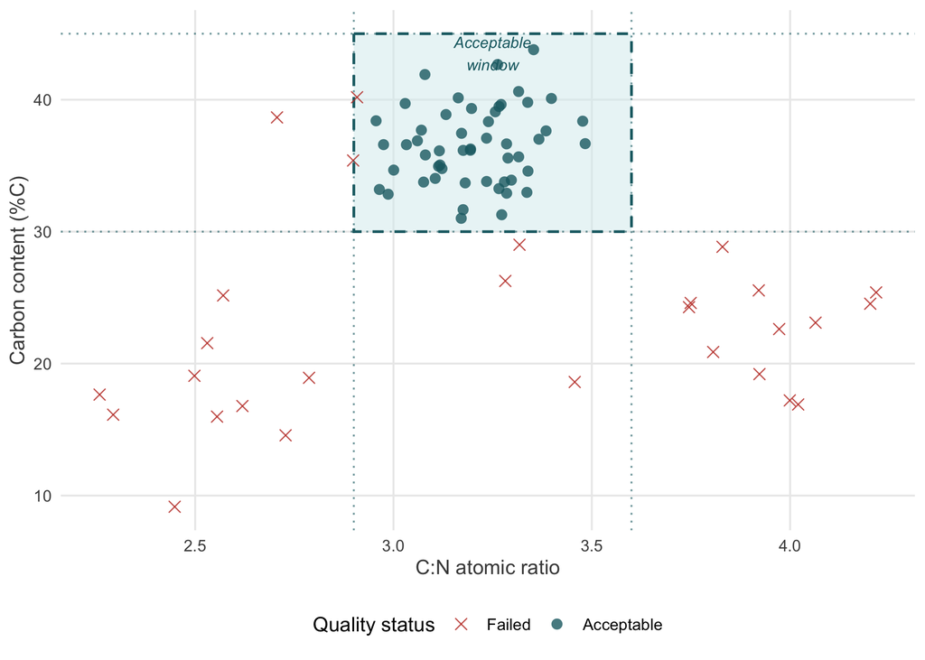

Figure 2: Schematic illustration of the DeNiro (1985) collagen quality acceptance window. Points within the shaded rectangle (C:N 2.9–3.6, %C 30–45 %) are considered acceptable for isotopic analysis. Points outside suggest diagenetic alteration or contamination.

Standard quality criteria for archaeological bone collagen:

Table 8: Collagen quality acceptance criteria for stable isotope analysis

| Criterion | Acceptable range | Reference |
| --- | --- | --- |
| C:N atomic ratio | 2.9 – 3.6 | DeNiro 1985 |
| Carbon content (%C) | 30 – 45 % | van Klinken 1999 |
| Nitrogen content (%N) | 11 – 16 % | van Klinken 1999 |
| Collagen yield | ≥ 1 % of bone dry weight | Longin 1971 (indicative) |

Specimens failing these criteria should be excluded from mixing-model datasets or treated as having substantially inflated uncertainty. In practice, the **C:N ratio** is the most widely used single criterion.

# 6 Learning Outcomes Checklist

By the end of this session you should be able to:

1. Define the delta notation (Equation 1) and explain why it is used in preference to absolute isotope ratios.
2. Describe the physical basis for <sup>13</sup>C fractionation during C<sub>3</sub> and C<sub>4</sub> photosynthesis, and explain its dietary significance.
3. Explain the trophic enrichment factor for δ<sup>15</sup>N and describe the range of values expected across a terrestrial food web (Table 3).
4. Define isotopic routing and explain why bone collagen δ<sup>13</sup>C preferentially reflects dietary protein carbon.
5. Distinguish the dietary integration windows of bone collagen, dentine, and soft tissues (Table 5).
6. Outline at least four distinct archaeological research questions amenable to isotope mixing-model analysis (Table 7).
7. Apply collagen quality criteria to evaluate whether a specimen is suitable for dietary isotope analysis (Table 8).
8. Articulate the link between dietary isotope mixing models and the Marine Reservoir Effect in radiocarbon dating.

# 7 Key Equations Reference

$$\delta X\ (\text{‰}) = \left[\frac{R_{\text{sample}}}{R_{\text{standard}}} - 1\right] \times 1000
\qquad \text{(delta notation)}$$

$$\Delta^{13}C = \delta^{13}C_{\text{tissue}} - \delta^{13}C_{\text{diet}}
\qquad \text{(carbon TEF)}$$

$$\Delta^{15}N = \delta^{15}N_{\text{tissue}} - \delta^{15}N_{\text{diet}}
\qquad \text{(nitrogen TEF)}$$

**Typical defaults (bone collagen vs. diet):** Δ<sup>13</sup>C ≈ +1.0 ‰ · Δ<sup>15</sup>N ≈ +4.0 ‰

**Collagen acceptance:** C:N = 2.9–3.6 · %C = 30–45 · %N = 11–16

# 8 Recommended Further Reading

Ambrose, S.H. & Norr, L. (1993) Experimental evidence for the relationship of the carbon isotope ratios of whole diet and dietary protein to those of bone collagen and carbonate. In: Lambert & Grupe (eds), *Prehistoric Human Bone*, pp. 1–37.

DeNiro, M.J. (1985) Postmortem preservation and alteration of *in vivo* bone collagen isotope ratios in relation to palaeodietary reconstruction. *Nature*, **317**, 806–809.

Hedges, R.E.M. & van Klinken, G.J. (1992) A review of current approaches in the pretreatment of bone for radiocarbon dating by AMS. *Radiocarbon*, **34**, 279–291.

Parnell, A.C., Inger, R., Bearhop, S. & Jackson, A.L. (2010) Source partitioning using stable isotopes: coping with too much variation. *PLoS ONE*, **5**, e9672.

Schoeninger, M.J. & DeNiro, M.J. (1984) Nitrogen and carbon isotopic composition of bone collagen from marine and terrestrial animals. *Geochimica et Cosmochimica Acta*, **48**, 625–639.

van der Merwe, N.J. & Vogel, J.C. (1978) <sup>13</sup>C content of human collagen as a measure of prehistoric diet in woodland North America. *Nature*, **276**, 815–816.

van Klinken, G.J. (1999) Bone collagen quality indicators for palaeodietary and radiocarbon measurements. *Journal of Archaeological Science*, **26**, 687–695.

*End of Module 1 — continue to Module 2: Mixing Model Fundamentals (09:30–10:30)*